# Korea NDI Analysis

coop711

2015년 4월 12일

## Data Management

- 원 자료에 나와 있는 항목들은 같은 이름들이 있기 때문에 자료를 손보는 과정에서 별도의 이름을 부여. 읽어들일 때 같은 이름이 있으면 `duplicate row.names not allowed Error` 가 나게 됨.

```r
NDI<-read.table("NDI_kor.txt", header=T, row.names=1)
NDI
```

```
##                          X1990 X1995 X2000 X2005 X2011
## 피용자보수                49.7  52.8  50.0  53.5  52.6
## 기업및재산소득            37.8  34.9  36.5  33.9  35.2
## 법인(금융기관포함)_1       9.4   9.2   6.9  11.6  16.2
## 일반정부_1                 0.8   0.8   1.5   1.0   0.8
## 가계및비영리단체_1        27.5  24.9  28.0  21.3  18.2
## 생산및수입세(공제)보조금  12.1  12.3  13.6  13.0  12.7
## 순수취경상이전             0.4   0.1   0.0  -0.4  -0.5
## 법인(금융기관포함)_2      -3.6  -3.8  -4.2  -5.5  -5.0
## 일반정부_2                 7.7   8.1  10.1  11.3  10.9
## 가계및비영리단체_2        -3.8  -4.3  -6.0  -6.3  -6.4
## 국민처분가능소득         100.0 100.0 100.0 100.0 100.0
## 법인(금융기관포함)_3       5.9   5.4   2.7   6.1  11.2
## 일반정부_3                20.7  21.2  25.2  25.3  24.4
## 가계및비영리단체_3        73.5  73.4  72.0  68.6  64.4
```

- 변수명 앞에 X가 붙는 이유에 대해서는 `?make.names` 에서 찾아 볼 것. 보기가 좀 거시기하므로 변수명을 다시 지정.

```r
dimnames(NDI)[[2]]<-c(1990, 1995, 2000, 2005, 2011)
NDI
```

```
##                           1990  1995  2000  2005  2011
## 피용자보수                49.7  52.8  50.0  53.5  52.6
## 기업및재산소득            37.8  34.9  36.5  33.9  35.2
## 법인(금융기관포함)_1       9.4   9.2   6.9  11.6  16.2
## 일반정부_1                 0.8   0.8   1.5   1.0   0.8
## 가계및비영리단체_1        27.5  24.9  28.0  21.3  18.2
## 생산및수입세(공제)보조금  12.1  12.3  13.6  13.0  12.7
## 순수취경상이전             0.4   0.1   0.0  -0.4  -0.5
## 법인(금융기관포함)_2      -3.6  -3.8  -4.2  -5.5  -5.0
## 일반정부_2                 7.7   8.1  10.1  11.3  10.9
## 가계및비영리단체_2        -3.8  -4.3  -6.0  -6.3  -6.4
## 국민처분가능소득         100.0 100.0 100.0 100.0 100.0
## 법인(금융기관포함)_3       5.9   5.4   2.7   6.1  11.2
## 일반정부_3                20.7  21.2  25.2  25.3  24.4
## 가계및비영리단체_3        73.5  73.4  72.0  68.6  64.4
```

- 이 작업에서 실제로 필요한 row는 `법인_3`, `일반정부_3`, `가계및비영리단체_1`, `가계및비영리단체_3` 뿐 이므로 `NDI.2`에 필요한 row만 옮김.

```r
NDI.2<-NDI[c(5, 12:14), ]
NDI.2
```

```
##                      1990 1995 2000 2005 2011
## 가계및비영리단체_1   27.5 24.9 28.0 21.3 18.2
## 법인(금융기관포함)_3  5.9  5.4  2.7  6.1 11.2
## 일반정부_3           20.7 21.2 25.2 25.3 24.4
## 가계및비영리단체_3   73.5 73.4 72.0 68.6 64.4
```

- 그림 그리는 과정에 자주 등장하게 되는 연도 변수를 `year`로 저장.

```r
year<-as.numeric(dimnames(NDI)[[2]])
year
```

```
## [1] 1990 1995 2000 2005 2011
```

- 그밖에 작업의 편의를 위하여 각각의 변수 새로 지정

```r
gov<-NDI.2[3,]
personal.1<-NDI.2[1,]
personal.3<-NDI.2[4,]
corp<-NDI.2[2,]
```

## Plots

- 각 항목이 `NDI` 대비 차지하는 비중을 알아보기 위함이므로 다음과 같은 방식으로 `plot()` 이용

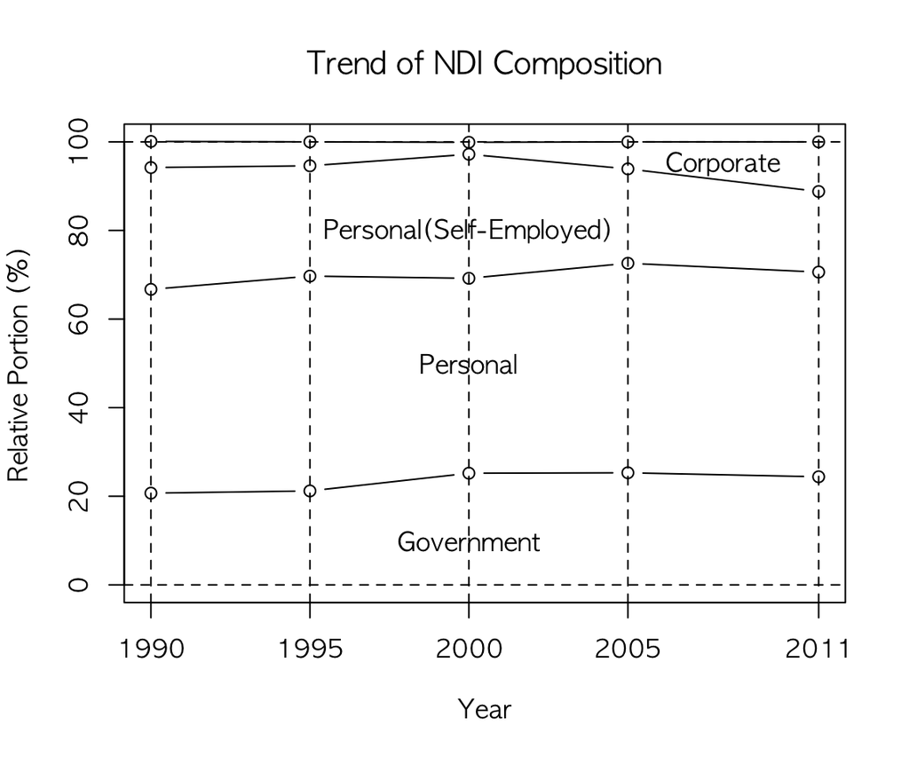

```r
plot(x=c(1990, 1995, 2000, 2005, 2011), y=gov, type="b", ylim=c(0,100), xaxt="n", yaxt="n", ann=F)
lines(x=c(1990, 1995, 2000, 2005, 2011), y=gov+personal.3, type="b")
lines(x=c(1990, 1995, 2000, 2005, 2011), y=gov+personal.3-personal.1, type="b")
lines(x=c(1990, 1995, 2000, 2005, 2011), y=gov+personal.3+corp, type="b")
text(x=2000, y=10, labels="Government")
text(x=2000, y=50, labels="Personal")
text(x=2000, y=80, labels="Personal(Self-Employed)")
text(x=2008, y=95, labels="Corporate")
abline(h=c(0,100), lty=2)
abline(v=year, lty=2)
axis(side=1, at=year, labels=year)
axis(side=2, at=seq(0, 100, by=20), labels=seq(0, 100, by=20))
title(main="Trend of NDI Composition", xlab="Year", ylab="Relative Portion (%)")
```

- 각 영역을 구분하기 위하여 빗금을 그으려면 `density` 와 `angle`을 설정

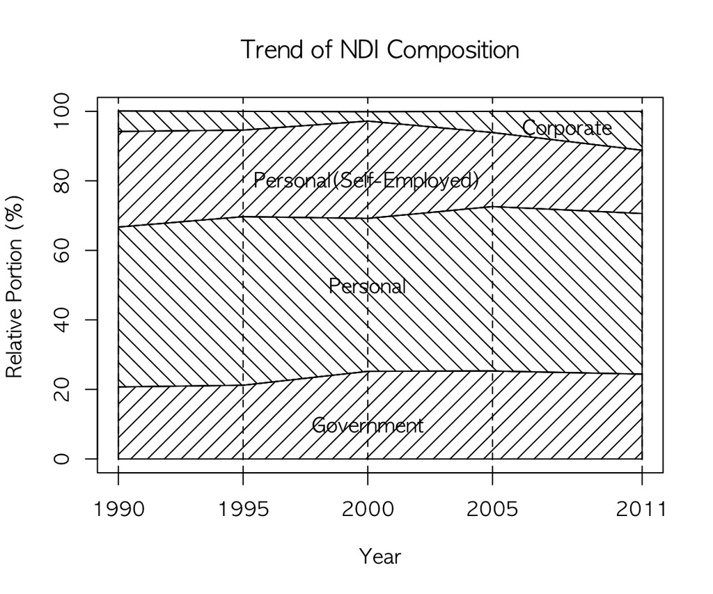

```r
plot(x=c(1990, 1995, 2000, 2005, 2011), y=gov, type="l", ylim=c(0,100), xaxt="n", yaxt="n", ann=F)
lines(x=c(1990, 1995, 2000, 2005, 2011), y=gov+personal.3, type="l")
lines(x=c(1990, 1995, 2000, 2005, 2011), y=gov+personal.3-personal.1, type="l")
lines(x=c(1990, 1995, 2000, 2005, 2011), y=gov+personal.3+corp, type="l")
polygon(x=c(year, rev(year)), y=c(rep(0, 5), rev(gov)), density=10, angle=45)
polygon(x=c(year, rev(year)), y=c(gov, rev(gov+personal.3-personal.1)), density=10, angle=135)
polygon(x=c(year, rev(year)), y=c(gov+personal.3-personal.1, rev(gov+personal.3)), density=10, angle=45)
polygon(x=c(year, rev(year)), y=c(gov+personal.3, rev(gov+personal.3+corp)), density=10, angle=135)
text(x=2000, y=10, labels="Government")
text(x=2000, y=50, labels="Personal")
text(x=2000, y=80, labels="Personal(Self-Employed)")
text(x=2008, y=95, labels="Corporate")
abline(v=year, lty=2)
axis(side=1, at=year, labels=year)
axis(side=2, at=seq(0, 100, by=20), labels=seq(0, 100, by=20))
title(main="Trend of NDI Composition", xlab="Year", ylab="Relative Portion (%)")
```

- 색깔로 구분하려면 굳이 `type="b"` 로 할 필요는 없고, 윤곽이 자연스럽게 구현되므로

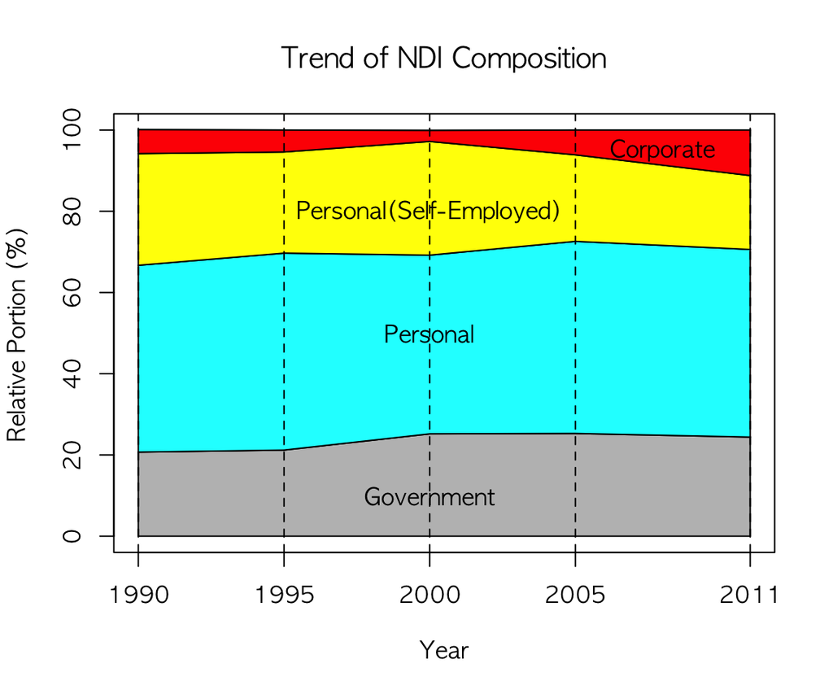

```r
plot(x=c(1990, 1995, 2000, 2005, 2011), y=gov, type="l", ylim=c(0,100), xaxt="n", yaxt="n", ann=F)
lines(x=c(1990, 1995, 2000, 2005, 2011), y=gov+personal.3, type="l")
lines(x=c(1990, 1995, 2000, 2005, 2011), y=gov+personal.3-personal.1, type="l")
lines(x=c(1990, 1995, 2000, 2005, 2011), y=gov+personal.3+corp, type="l")
polygon(x=c(year, rev(year)), y=c(rep(0, 5), rev(gov)), col="grey")
polygon(x=c(year, rev(year)), y=c(gov, rev(gov+personal.3-personal.1)), col="cyan")
polygon(x=c(year, rev(year)), y=c(gov+personal.3-personal.1, rev(gov+personal.3)), col="yellow")
polygon(x=c(year, rev(year)), y=c(gov+personal.3, rev(gov+personal.3+corp)), col="red")
text(x=2000, y=10, labels="Government")
text(x=2000, y=50, labels="Personal")
text(x=2000, y=80, labels="Personal(Self-Employed)")
text(x=2008, y=95, labels="Corporate")
abline(v=year, lty=2)
axis(side=1, at=year, labels=year)
axis(side=2, at=seq(0, 100, by=20), labels=seq(0, 100, by=20))
title(main="Trend of NDI Composition", xlab="Year", ylab="Relative Portion (%)")
```

- 컬러 인쇄가 어려운 형편이라면 `gray()`를 이용하여 설정.

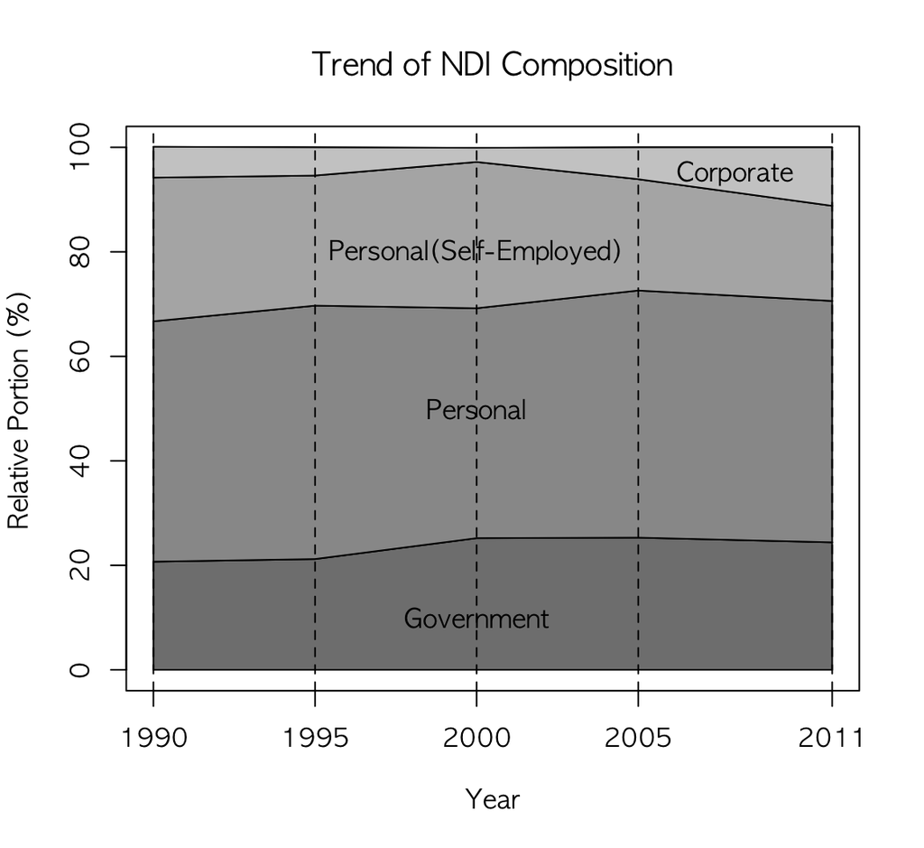

```r
plot(x=c(1990, 1995, 2000, 2005, 2011), y=gov, type="l", ylim=c(0,100), xaxt="n", yaxt="n", ann=F)
lines(x=c(1990, 1995, 2000, 2005, 2011), y=gov+personal.3, type="l")
lines(x=c(1990, 1995, 2000, 2005, 2011), y=gov+personal.3-personal.1, type="l")
lines(x=c(1990, 1995, 2000, 2005, 2011), y=gov+personal.3+corp, type="l")
polygon(x=c(year, rev(year)), y=c(rep(0, 5), rev(gov)), col=gray(level=0.5))
polygon(x=c(year, rev(year)), y=c(gov, rev(gov+personal.3-personal.1)), col=gray(level=0.6))
polygon(x=c(year, rev(year)), y=c(gov+personal.3-personal.1, rev(gov+personal.3)), col=gray(level=0.7))
polygon(x=c(year, rev(year)), y=c(gov+personal.3, rev(gov+personal.3+corp)), col=gray(level=0.8))
text(x=2000, y=10, labels="Government")
text(x=2000, y=50, labels="Personal")
text(x=2000, y=80, labels="Personal(Self-Employed)")
text(x=2008, y=95, labels="Corporate")
abline(v=year, lty=2)
axis(side=1, at=year, labels=year)
axis(side=2, at=seq(0, 100, by=20), labels=seq(0, 100, by=20))
title(main="Trend of NDI Composition", xlab="Year", ylab="Relative Portion (%)")
```

- 한글로 텍스트를 붙이려면

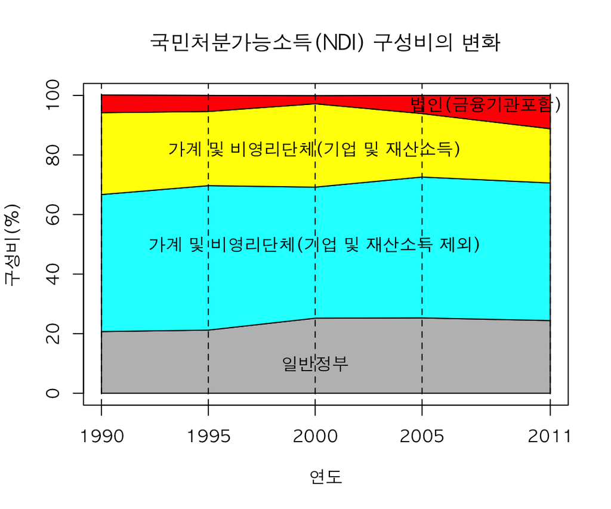

```r
plot(x=c(1990, 1995, 2000, 2005, 2011), y=gov, type="l", ylim=c(0,100), xaxt="n", yaxt="n", ann=F)
lines(x=c(1990, 1995, 2000, 2005, 2011), y=gov+personal.3, type="l")
lines(x=c(1990, 1995, 2000, 2005, 2011), y=gov+personal.3-personal.1, type="l")
lines(x=c(1990, 1995, 2000, 2005, 2011), y=gov+personal.3+corp, type="l")
polygon(x=c(year, rev(year)), y=c(rep(0, 5), rev(gov)), col="grey")
polygon(x=c(year, rev(year)), y=c(gov, rev(gov+personal.3-personal.1)), col="cyan")
polygon(x=c(year, rev(year)), y=c(gov+personal.3-personal.1, rev(gov+personal.3)), col="yellow")
polygon(x=c(year, rev(year)), y=c(gov+personal.3, rev(gov+personal.3+corp)), col="red")
text(x=2000, y=10, labels="일반정부")
text(x=2000, y=50, labels="가계 및 비영리단체(기업 및 재산소득 제외)")
text(x=2000, y=82, labels="가계 및 비영리단체(기업 및 재산소득)")
text(x=2008, y=97, labels="법인(금융기관포함)")
abline(v=year, lty=2)
axis(side=1, at=year, labels=year)
axis(side=2, at=seq(0, 100, by=20), labels=seq(0, 100, by=20))
title(main="국민처분가능소득(NDI) 구성비의 변화", xlab="연도", ylab="구성비(%)")
```